# act_report

## Report: act_report

- Create a **250-word-minimum written report** called "act_report.pdf" or "act_report.html" that communicates the insights and displays the visualization(s) produced from your wrangled data. This is to be framed as an external document, like a blog post or magazine article, for example.

The subject dataset to be worked upon is the tweet archive of Twitter user @dog_rates, also known as WeRateDogs. WeRateDogs is a Twitter account that rates people's dogs with a humorous comment about the dog. These ratings almost always have a denominator of 10. The numerators, though? Almost always greater than 10.

The dataset were to be gathered from 3 different sources.

1. Directly from WeRateDogs twitter archive data that was provided in the project description.
2. I also had to use the request library to access WeRateDogs tweet image predictions hosted on udacity
3. The third dataset of WeRateDogs twitter account was directly acccessed via Twitter's API or each tweet's JSON data using Python's Tweepy library and stored each tweet's entire set of JSON data in a file called tweet_json.txt file. Each lines was then read and converted to a dataframe with tweet ID, retweet count, and favorite count as columns.

### Insights and Visualization

The statistical description of the dataset revealed the numerical characteristics of the cleaned dataset.

We can see that the rating denominator is set at 10 as corrcetd in the data cleaning.

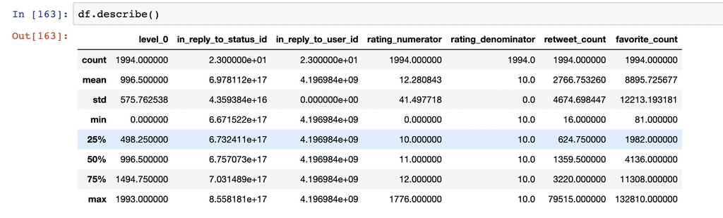

Grouping the retweet's count by the timestamp (year) we are able to see that 2016 had the most count of retweets.

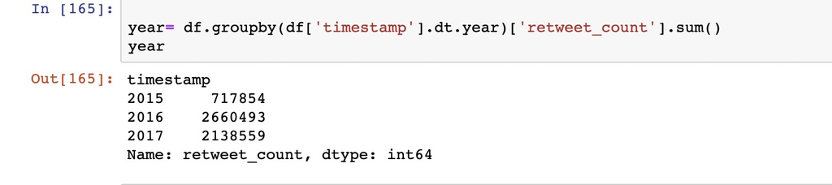

We picked the ratings that are above 10 and grouped them by the dog stages. We found that the dog with the highest average rating is puppo with a n avaerage of 12.18

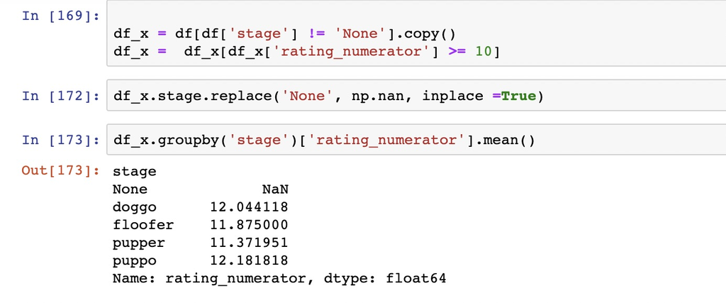

During analysis of the names, The most common name is Charlie

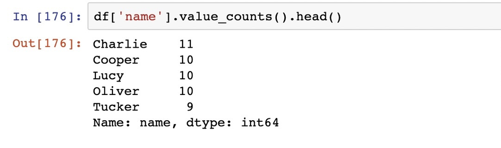

### Insights:

[figure not shown]

The distribution of the ratings showed that the general ratings are concentrated between 10 and 14. It happened that the outlier value of 27 is not then really significant in the grand scheme of ratings.

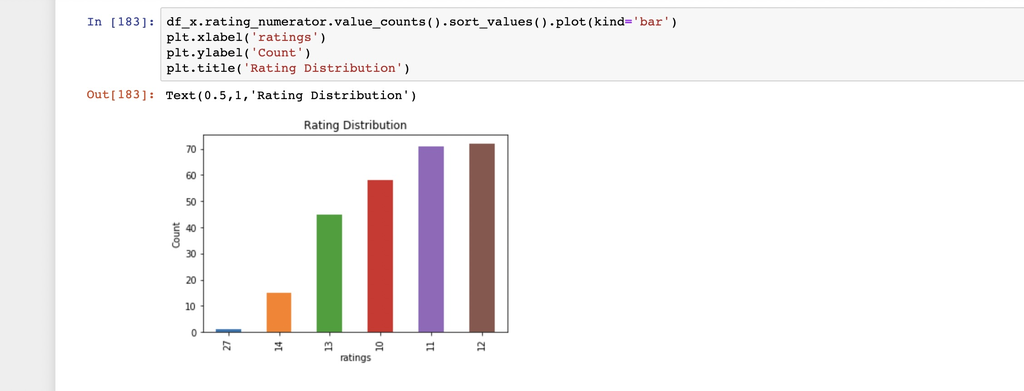

The new dog_breed column was created based on the img_num prediction column.

The top 15 most common dog breed are displayed in the bar plot. There is also an attempt to check the most common dog breed. We found that Labrador Retriever is the most common dog breed followed by the Chihuahua

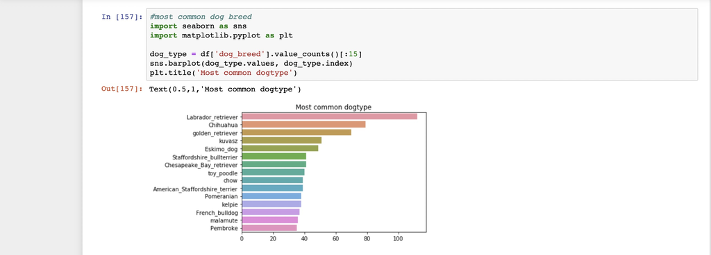

We also analysed the sources from which each tweets were made and we found that "Iphone" users constitues majority of the tweets ratings made about dogs.

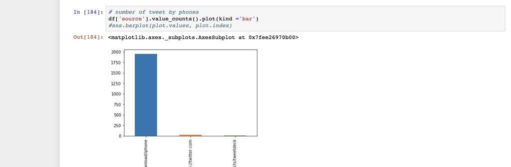